# W23_APS1070_Project_4_SachinVerma

## Part 1 - Getting Started

In this project, we are going to design a mathematical model that predicts the critical temperature of a superconductor, as described in the paper below:

*Hamidieh, Kam, A data-driven statistical model for predicting the critical temperature of a superconductor, Computational Materials Science, Volume 154, November 2018, Pages 346-354*

The following dataset contains 21263 instances, where each instance is a set of 81 features describing the superconductor's status. Our goal is to use these features to predict the `critical_temp` column, which is a setting that the design should take into account. We will make our predictions by implementing linear regression.

```python
from sklearn.metrics import mean_squared_error
import numpy as np
import pandas as pd
import matplotlib.pyplot as plt
%config InlineBackend.figure_format = "retina"
import scipy
import time
from tqdm.notebook import tqdm
from sklearn.model_selection import train_test_split


df=pd.read_csv("https://raw.githubusercontent.com/APS1070-W23/datasets/main/superconduct.csv" , skipinitialspace=True)
```

Here are the steps to complete this portion:

1. Print the dataframe.
2. Prepare your dataset as follows: **[1.5]**
- Using `train_test_split` from Sklearn, split the dataset into training and validation sets ($80\%$ training, $20\%$ validation). When splitting, set `random_state=1`. **[0.5]**
- Standardize the data **manually** according to the same method as `StandardScaler` from sklearn, but you may not directly use `StandardScaler'. **[0.5]**
- Insert a first column of all $1$s in both the training and validation data sets. **[0.5]**
1. Explain why we should not insert the column of $1$s prior to standardization. **[0.5]**

   *Answer*: We should not insert the column of 1's prior to standardization as its variance is zero and thus the standardization is ill-defined.

```python
# df.head()
# # df.info()
df.shape
```

```
(21263, 82)
```

```python
X_train, X_val, y_train, y_val = train_test_split(df.iloc[:, 0:-1],
                                                  df.iloc[:,-1],
                                                  test_size=0.20,
                                                  random_state=1)

def standardize(pandas_data):
  mu,sigma = pandas_data.mean(), pandas_data.std()
  data_copy = pandas_data.copy()
  data_copy -= mu
  data_copy /= sigma
  return data_copy, mu, sigma

X_train_std, mu, sigma = standardize(X_train)
# X_val_std = standardize(X_val)
X_val_std = X_val.copy()
X_val_std -= mu
X_val_std /= sigma

X_train_std.insert(0, 'bias', np.ones(X_train.shape[0]))
X_val_std.insert(0, 'bias', np.ones(X_val.shape[0]))
```

## Part 2 - Linear Regression Using Direct Solution

Implement the direct solution of the linear regression problem on the training set. **[0.5]**

**Note: You should use scipy.linalg.inv to perform the inversion, as numpy.linalg.inv may caue an error.**

Report the root-mean-square error (RMSE) for both the training and validation sets. **[0.5]**

You may use `mean_squared_error` from Sklearn for computing the RMSE.

```python
def rmse(yPred, y):
    return np.sqrt(mean_squared_error(yPred, y))

W = np.dot(scipy.linalg.inv(np.dot(X_train_std.values.T, X_train_std.values)), np.dot(X_train_std.values.T, y_train.values))

yPred_train = np.dot(X_train_std.values, W)
rmse_direct_soln_train = rmse(yPred_train, y_train.values)
print("RMSE Training Set: ", rmse_direct_soln_train)

yPred_val = np.dot(X_val_std.values, W)
rmse_direct_soln_val = rmse(yPred_val, y_val.values)
print("RMSE Validaton Set: ", rmse_direct_soln_val)
```

```
RMSE Training Set:  17.49502514032637
RMSE Validaton Set:  17.840340542380567
```

## Part 3 - Full Batch Gradient Descent

We will now implement a "full batch" gradient descent algorithm and record the training time for our model. Recall that the full batch gradient descent is $$w_t = w_{t-1} - \alpha~g_t$$ where $\alpha$ is the learning rate and $g_t$ is your gradient, computed on the entire data.

Here are the steps for this part:

- Implement gradient descent for linear regression using a fixed learning rate of $\alpha= 0.01$, and iterate until your model's **validation** RMSE converges.

  We consider the gradient descent as having converged when RMSE on the validation set using gradient descent satisfies:

  $$ RMSE_\text{GD} \leq 1.001 \times RMSE_\text{Direct Solution}$$

  where $RMSE_\text{Direct Solution}$ is the RMSE on the validation set using the direct solution that you calculated in the previous part.

  We refer to the quantity $RMSE_\text{Direct Solution}\times 1.001$ as the convergence threshold (CT).
- Record the training time (from the first iteration until convergence) using the `time.time()` function. Be sure to compute the gradients yourself! Take a look at the code provided in the tutorial. **[1]**
- Plot the training RMSE and the validation RMSE vs. epoch on the same figure. **[1]**
- Comment on overfitting/underfitting by observing the training and validation RMSE **[1]**

**Hint**: Initialize your weights with small random numbers (<$0.001$)

```
Full Batch Gradient Descent [alpha: 0.01]
Epochs Trained: 21737
Converged:  True
RMSE Training Set:  17.57263
Time Elapsed (s) :  214.26
===============================================================================
```

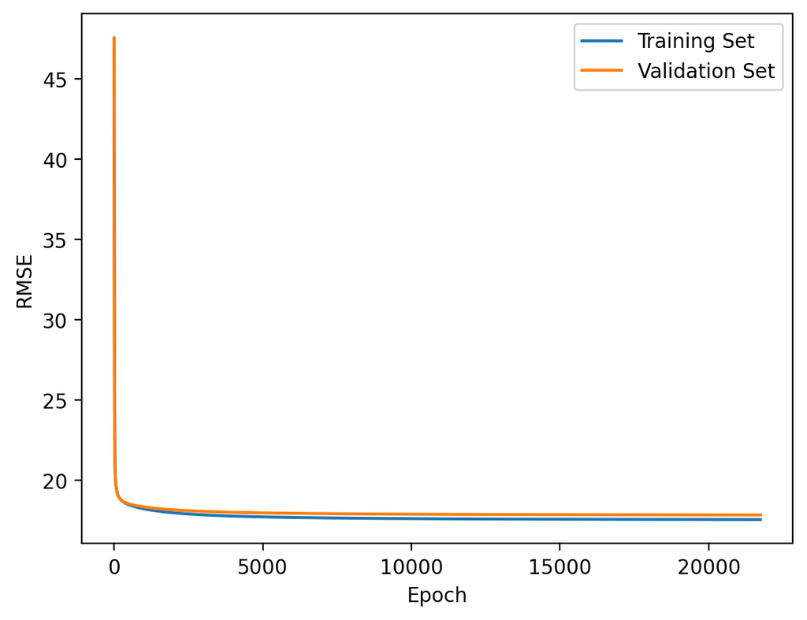

```
RMSE Validation Set (Full Batch Gradient Descent):  17.85818
```

```python
start_time = time.time() ## Records current time

w = (np.random.random(X_train_std.shape[1])).reshape(1,-1) ### Inital weights
lr = .01  ### Learning rate
rmse_train_epoch= []
rmse_val_epoch= []
elapsed_time_epoch = []
convg_threshold = 1.001 * rmse_direct_soln_val
max_epochs = 100000

X_train_std_arr = X_train_std.to_numpy()
X_val_std_arr = X_val_std.to_numpy()
y_train_arr = y_train.to_numpy().reshape(-1,1)
y_val_arr = y_val.to_numpy().reshape(-1,1)
N_train = len(y_train_arr)
converged = False
v_t = np.zeros(X_train_std_arr.shape[1])

print(f"Full Batch Gradient Descent [alpha: {lr}]")

for epoch in range (1, max_epochs+1):
  y_pred_train = np.dot(X_train_std_arr, w.T)
  y_pred_val = np.dot(X_val_std_arr, w.T)
  rmse_train_epoch.append(rmse(y_pred_train, y_train_arr))
  rmse_val_epoch.append(rmse(y_pred_val,y_val_arr))
  print1= np.round(rmse_train_epoch[-1],4)
  print2 = np.round(rmse_val_epoch[-1],4)
  print("\rEpoch:", epoch,"/",max_epochs, "| RMSE Training Set: ", print1,
          "| RMSE Validation Set: ", print2, end='')

  if rmse_val_epoch[-1] <= convg_threshold:
    converged = True
    break

  # Update Weights using Gradient Descent
  grad = (1/N_train) * np.dot(X_train_std_arr.T, y_pred_train-y_train_arr)
  v_t = 0.8 * v_t + lr * grad.T
  w = w - v_t
  elapsed_time_epoch.append(time.time() - start_time)

  if epoch == max_epochs:
    print("\nMax iteration limit reached.")
    print(f"===============================================================================\n")

if converged:
  print('\r', end='')
  print(f"Epochs Trained: {epoch}")
  print("Converged: ", converged)
  print("RMSE Training Set: ", np.round(rmse_train_epoch[-1],5))
  print("Time Elapsed (s) : ", np.round(elapsed_time_epoch[-1],3))
  print(f"===============================================================================\n")

# print ("X: ", X_train_std.shape)
# print ("w: ", w.shape)
# print ("y: ", y_train_arr.shape)
# print ("t: ", y_pred_train.shape)
# print ("gradient: ", gradient.shape)

plt.plot(rmse_train_epoch, label='Training Set')
plt.plot(rmse_val_epoch, label='Validation Set')
plt.legend()
plt.xlabel("Epoch")
plt.ylabel("RMSE")
plt.show()

print("RMSE Validation Set (Full Batch Gradient Descent): ", np.round(rmse_val_epoch[-1],5))
```

For the converged model, both the training and validation RMSE values are comparable and they both fall within the set convergence threshold. Therefore, this model shows a good fit; neither overfit nor under fit.

## Part 4 - Mini-batch and Stochastic Gradient Descent

Write a function that performs mini-batch gradient descent until the convergence threshold (CT) is reached. **[1]**

The inputs of that function are:

- Input data (training/validation), Batch size, Learning Rate, Convergence Threshold (CT)

Your function will return the following arrays:

- The final weights after training.
- The training RMSE at each epoch.
- The validation RMSE at each epoch.
- An array that has the elapsed time from the start of the training process to the end of each epoch (e.g., if each epoch takes exactly 2 seconds, the array would look like: [2 4 6 8 ...]).

Notes:

- For certain batch sizes, GD might not converge to a solution. For that reason, you need to check the RMSE of the validation/training set at each epoch, and if it's getting larger and larger, you should stop the training for that case (the design is up to you!).
- CT will help you to know when your model is converged.
- **Important: after each epoch, you need to shuffle the entire training set.** This ensures that new mini-batches are selected for every epoch. Hint: use `np.random.permutation`.

Let's now use the function to investigate the effect of batch size on convergence. When the batch size is 1, we call that stochastic gradient descent. When the batch size equals the # of training data, it is full-batch (i.e., all data points are used at every iteration). Anywhere in between is mini-batch (we use some of the data).

- Sweep different values for the mini-batch size (at least 5 values that **converge**), each time using a learning rate of $\alpha= 0.01$. **Hint: Try batch sizes that are powers of two (e.g., 2,4,8,16,32,64,128...).** These batch sizes fit better on the hardware and may achieve higher performance. **[0.5]**

Provide the following $3$ plots:

1. Plot training and validation RMSE vs. **epoch** for all the **converging** batch sizes (some batch sizes might not converge) in a figure. The X-axis is Epoch # and the Y-axis is RMSE. **[0.5]**
2. Plot training and validation RMSE vs. **time** for all the **converging** batch sizes in a figure. The X-axis is Time, and the Y-axis is RMSE. **[0.5]**
3. Plot Total training time (y-axis) vs. Batch size (x-axis). **[0.5]**

Describe your findings, including the main takeaways from each of your plots. **[1]**

#### Mini Batch Gradient Descent With Momentum

```python
def mini_batch_GD(X_train, y_train, X_val, y_val, batch_size, lr, convg_threshold):

  rmse_train_batch = []
  rmse_train_epoch= []
  rmse_val_epoch= []
  elapsed_time_epoch = []

  y_val = y_val.reshape(-1,1)

  np.random.seed(1007)
  w = (np.random.random(X_train.shape[1])).reshape(1,-1) ### Inital weights

  max_epochs = 100000
  total_samples = len(y_train)
  nbatches = int(np.ceil(total_samples/batch_size))
  wrap_around = int((nbatches * batch_size) - total_samples)
  converged = False

  print(f"Mini-Batch Gradient Descent [Batch Size: {batch_size} | alpha: {lr}]")

  start_time = time.time()
  v_t = np.zeros(X_train.shape[1])
  ma_frame_size = 25   #moving average window

  for epoch in range(1, max_epochs+1):
    seed = np.random.randint(1, 1000)
    np.random.seed(seed)
    X = np.random.permutation(X_train)
    np.random.seed(seed)
    y = np.random.permutation(y_train)
    y = y.reshape(-1,1)
    for batch in range(1, nbatches+1):
      start_index = (batch-1)*batch_size
      end_index = start_index + batch_size
      X_batch = X[start_index:end_index, :]
      y_batch = y[start_index:end_index]

      if batch == nbatches:
        X_batch = np.vstack((X[start_index:-1, :], X[0:wrap_around+1, :]))
        y_batch = np.vstack((y[start_index:-1], y[0:wrap_around+1]))

      y_pred = np.dot(X_batch, w.T)
      rmse_train_batch.append(rmse(y_pred, y_batch))

      if rmse_train_batch[-1] > 1e3:
        print(f"RMSE > 1e3. Run aborted.")
        print(f"Epochs Trained: {epoch-1}")
        print("Converged: ", converged)
        try:
          print("Time Elapsed (s) : ", np.round(elapsed_time_epoch[-1],3))
        except:
          print("Time Elapsed (s) : NA ")
        print(f"===============================================================================\n")
        return None, None, None, None, False


      ## Gradient Descent with Momentum
      grad = (1/batch_size) * np.dot(X_batch.T, y_pred-y_batch)
      v_t = 0.8 * v_t + lr * grad.T
      w = w - v_t


    elapsed_time_epoch.append(time.time() - start_time)
    y_pred_train = np.dot(X_train, w.T)
    y_pred_val = np.dot(X_val, w.T)
    rmse_train_epoch.append(rmse(y_pred_train, y_train))
    rmse_val_epoch.append(rmse(y_pred_val, y_val))
    print1= np.round(rmse_train_epoch[-1],4)
    print2 = np.round(rmse_val_epoch[-1],4)
    print("\rEpoch:", epoch,"/",max_epochs, "| RMSE Training Set: ", print1,
          "| RMSE Validation Set: ", print2, end='')


    if epoch > 2*ma_frame_size:
       moving_avg = np.sum(rmse_val_epoch[-ma_frame_size-1:])/ma_frame_size
       moving_avg_prev = np.sum(rmse_val_epoch[-2*ma_frame_size-1:-ma_frame_size])/ma_frame_size
       if moving_avg >= moving_avg_prev:
         print('\r', end='')
         print(f"RMSE Moving Average Divergence in last {ma_frame_size} epochs. Run aborted.")
         print(f"Epochs Trained: {epoch}")
         print("Converged: ", converged)
         print("Time Elapsed (s) : ", np.round(elapsed_time_epoch[-1],3))
         print(f"===============================================================================\n")
         return None, None, None, None, False


    if rmse_val_epoch[-1] <= convg_threshold:
      converged = True
      break

  convergence_band = max(rmse_val_epoch[-ma_frame_size-1:]) - min(rmse_val_epoch[-ma_frame_size-1:])

  # Check for Oscillatory Convergence
  if convergence_band/convg_threshold > 0.01:
    converged = False
    print('\r', end='')
    print("Oscillatory Convergence. Batch Size Discarded")
  else:
    print('\r', end='')

  print(f"Epochs Trained: {epoch}")
  print("Converged: ", converged)
  print("RMSE Training Set: ", np.round(rmse_train_epoch[-1],5))
  print("RMSE Validation Set: ", np.round(rmse_val_epoch[-1],5))
  print("Time Elapsed (s) : ", np.round(elapsed_time_epoch[-1],3))
  print(f"===============================================================================\n")
  return w, rmse_train_epoch, rmse_val_epoch, elapsed_time_epoch, converged
```

```python
batch_sizes = [2048, 1024, 512, 256, 128, 64, 32, 16, 8, 4, 2]
batch_sensitivity = []

for batch_size in tqdm(batch_sizes):
  data = mini_batch_GD(X_train=X_train_std.to_numpy(),
                y_train=y_train.to_numpy(),
                X_val =X_val_std.to_numpy(),
                y_val =y_val.to_numpy(),
                batch_size=batch_size,
                lr=0.01,
                convg_threshold=1.001*rmse_direct_soln_val)
  batch_sensitivity.append(data)
```

```
Mini-Batch Gradient Descent [Batch Size: 2048 | alpha: 0.01]
Epochs Trained: 2268
Converged:  True
RMSE Training Set:  17.57672
RMSE Validation Set:  17.85799
Time Elapsed (s) :  96.215
===============================================================================

Mini-Batch Gradient Descent [Batch Size: 1024 | alpha: 0.01]
Epochs Trained: 993
Converged:  True
RMSE Training Set:  17.58989
RMSE Validation Set:  17.85803
Time Elapsed (s) :  44.824
===============================================================================

Mini-Batch Gradient Descent [Batch Size: 512 | alpha: 0.01]
Epochs Trained: 566
Converged:  True
RMSE Training Set:  17.58562
RMSE Validation Set:  17.85732
Time Elapsed (s) :  28.754
===============================================================================

Mini-Batch Gradient Descent [Batch Size: 256 | alpha: 0.01]
Epochs Trained: 237
Converged:  True
RMSE Training Set:  17.60836
RMSE Validation Set:  17.85545
Time Elapsed (s) :  14.367
===============================================================================

Mini-Batch Gradient Descent [Batch Size: 128 | alpha: 0.01]
Oscillatory Convergence. Batch Size Discarded
Epochs Trained: 292
Converged:  False
RMSE Training Set:  17.61278
RMSE Validation Set:  17.85793
Time Elapsed (s) :  26.026
===============================================================================
```

[output cut: 29 more lines]

```
===============================================================================

Mini-Batch Gradient Descent [Batch Size: 4 | alpha: 0.01]
Epoch: 8 / 100000 | RMSE Training Set:  106.1962 | RMSE Validation Set:  105.0206RMSE > 1e3. Run aborted.
Epochs Trained: 8
Converged:  False
Time Elapsed (s) :  8.528
===============================================================================

Mini-Batch Gradient Descent [Batch Size: 2 | alpha: 0.01]
RMSE > 1e3. Run aborted.
Epochs Trained: 0
Converged:  False
Time Elapsed (s) : NA
===============================================================================
```

#### Mini Batch Gradient Descent Plots

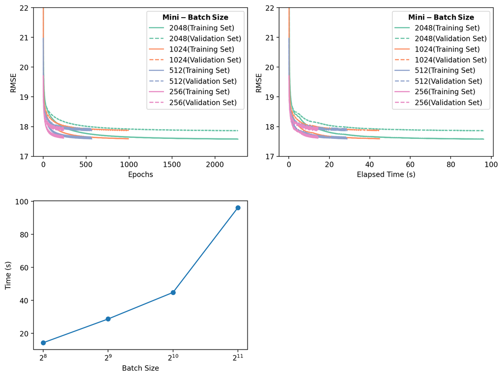

```python
import seaborn as sns
# batch_sizes
# batch_sensitivity => w, rmse_train_epoch, rmse_val_epoch, elapsed_time_epoch, converged
clrs = sns.color_palette('Set2')
legend = []
label_fontsize = 10
fig = plt.figure(figsize=(10,8))
ax = fig.add_subplot(2,2,1)
i = 0
for batch_data in batch_sensitivity:
  if batch_data[-1]:
    ax.plot(batch_data[1], color=clrs[i])
    ax.plot(batch_data[2], linestyle='dashed', color=clrs[i])
    plt.ylim([int(rmse_direct_soln_val), int(rmse_direct_soln_val*1.25) ])
    legend.append(str(batch_sizes[i])+"(Training Set)")
    legend.append(str(batch_sizes[i])+"(Validation Set)")
  i += 1
plt.legend(legend, title=r'$\bf{Mini-Batch\:Size}$');
plt.ylabel('RMSE', size=label_fontsize);
plt.xlabel('Epochs', size=label_fontsize);

i=0
ax = fig.add_subplot(2,2,2)
for batch_data in batch_sensitivity:
  if batch_data[-1]:
    ax.plot(batch_data[3], batch_data[1], color=clrs[i])
    ax.plot(batch_data[3], batch_data[2], linestyle='dashed', color=clrs[i])
    plt.ylim([int(rmse_direct_soln_val), int(rmse_direct_soln_val*1.25) ])
    legend.append(str(batch_sizes[i])+"(Training Set)")
    legend.append(str(batch_sizes[i])+"(Validation Set)")
  i += 1
plt.legend(legend, title=r'$\bf{Mini-Batch\:Size}$');
plt.ylabel('RMSE', size=label_fontsize);
plt.xlabel('Elapsed Time (s)', size=label_fontsize);

i=0
ax = fig.add_subplot(2,2,3)
elapsed_time_data = []
converged_batch = []
for batch_data in batch_sensitivity:
  if batch_data[-1]:
    elapsed_time_data.append(batch_data[3][-1])
    converged_batch.append(batch_sizes[i])
  i += 1

ax.plot(converged_batch, elapsed_time_data, '-o')
plt.xscale('log', base=2)
plt.ylabel('Time (s)', size=label_fontsize);
plt.xlabel('Batch Size', size=label_fontsize);

fig.tight_layout()
fig.subplots_adjust(hspace=0.3)
fig.subplots_adjust(top=0.92)
```

**Observations for Mini-batch GD with fixed learning rate of 0.01:**

1. In the first plot, we see that with the number of epochs to converegence decreases as the batch-size decreases. This is because with lower the batch size, there are higher the number of gradient steps per epoch. However, with reducing batch size, oscillatory convergence behavior gets pronounced.
2. In the second plot, we see the RMSE history w.r.t to elapsed time which updates with every epoch. This again shows a similar trend where the elpased time reduces with reducing batch size.
3. The third plot shows the total convergence time for each converged batch-sizes which relates to the last data point from the second figure.

It should be noted that the positive correlation between batch size and time cannot be generalized. If the batch size is reduced further, the convergence time or per-epoch solving time might increase. For the cases not shown in the plots (128 and 64 batch size), the total time to convergence is higher.

## Part 5 - Gradient Descent Learning Rate

Use the function that you designed in Part 4 to investigate the effect of learning rate on convergence.

1. Pick 3 batch sizes that do not converge with a learning rate of $\alpha= 0.01$ (last part) and try to find a learning rate that results in convergence for each batch size. Report your findings in a table. Mention batch size, learning rate, and training and validation RMSE. **[1]**
2. Select the best batch size based on Part 4's fastest convergence time and sweep the learning rate (at least 10 values, all should converge) while applying Mini-batch GD.
   - Plot the training and validation RMSE vs. **epoch** (x-axis) for all the learning rates that you tried in a figure. **[0.5]**
   - Plot the training and validation RMSE vs. **time** (x-axis) for all the learning rates that you tried in a figure. **[0.5]**
   - Describe your findings, including the main takeaways from each of your plots. **[1]**

```python
batch_sizes = [64, 16, 8]

learning_rates = [5.0e-3, 1.0e-3, 5.0e-4]

lr_sensitivity = []
batch_lr_sensitivity = []

for batch_size in tqdm(batch_sizes):
  batch_convg = False
  for alpha in learning_rates:

    if batch_convg:
      continue

    data = mini_batch_GD(X_train=X_train_std.to_numpy(),
                  y_train=y_train.to_numpy(),
                  X_val =X_val_std.to_numpy(),
                  y_val =y_val.to_numpy(),
                  batch_size=batch_size,
                  lr=alpha,
                  convg_threshold=1.001*rmse_direct_soln_val)
    if data[-1]:
      batch_convg = True



    lr_sensitivity.append(data)
  batch_lr_sensitivity.append(lr_sensitivity)
```

```
Mini-Batch Gradient Descent [Batch Size: 64 | alpha: 0.005]
Oscillatory Convergence. Batch Size Discarded
Epochs Trained: 175
Converged:  False
RMSE Training Set:  17.61851
RMSE Validation Set:  17.85617
Time Elapsed (s) :  24.236
===============================================================================

Mini-Batch Gradient Descent [Batch Size: 64 | alpha: 0.001]
Epochs Trained: 761
Converged:  True
RMSE Training Set:  17.58217
RMSE Validation Set:  17.85807
Time Elapsed (s) :  103.898
===============================================================================

Mini-Batch Gradient Descent [Batch Size: 16 | alpha: 0.005]
RMSE Moving Average Divergence in last 25 epochs. Run aborted.
Epochs Trained: 452
Converged:  False
Time Elapsed (s) :  150.724
===============================================================================

Mini-Batch Gradient Descent [Batch Size: 16 | alpha: 0.001]
Epochs Trained: 198
Converged:  True
RMSE Training Set:  17.62991
RMSE Validation Set:  17.85796
Time Elapsed (s) :  66.38
===============================================================================

Mini-Batch Gradient Descent [Batch Size: 8 | alpha: 0.005]
RMSE Moving Average Divergence in last 25 epochs. Run aborted.
Epochs Trained: 56
Converged:  False
Time Elapsed (s) :  31.982
===============================================================================

Mini-Batch Gradient Descent [Batch Size: 8 | alpha: 0.001]
Oscillatory Convergence. Batch Size Discarded
Epochs Trained: 186
Converged:  False
RMSE Training Set:  17.62298
RMSE Validation Set:  17.85732
Time Elapsed (s) :  105.497
===============================================================================

Mini-Batch Gradient Descent [Batch Size: 8 | alpha: 0.0005]
Epochs Trained: 225
Converged:  True
RMSE Training Set:  17.60549
RMSE Validation Set:  17.85754
Time Elapsed (s) :  128.164
===============================================================================
```

**Summary of mini-batch GD with learning rates that converged for Batch size: 64, 16 and 8**

[output not shown]

```python
batch_size = 256
learning_rates = 1e-3 * np.array([20, 16, 12, 10, 8, 6, 4, 2, 1, 0.8])

lr_sensitivity = []


for alpha in tqdm(learning_rates):
  data = mini_batch_GD(X_train=X_train_std.to_numpy(),
                y_train=y_train.to_numpy(),
                X_val =X_val_std.to_numpy(),
                y_val =y_val.to_numpy(),
                batch_size=batch_size,
                lr=alpha,
                convg_threshold=1.001*rmse_direct_soln_val)

  lr_sensitivity.append(data)
```

```
Mini-Batch Gradient Descent [Batch Size: 256 | alpha: 0.02]
Oscillatory Convergence. Batch Size Discarded
Epochs Trained: 201
Converged:  False
RMSE Training Set:  17.59043
RMSE Validation Set:  17.85651
Time Elapsed (s) :  12.895
===============================================================================

Mini-Batch Gradient Descent [Batch Size: 256 | alpha: 0.016]
Epochs Trained: 185
Converged:  True
RMSE Training Set:  17.62703
RMSE Validation Set:  17.85774
Time Elapsed (s) :  11.975
===============================================================================

Mini-Batch Gradient Descent [Batch Size: 256 | alpha: 0.012]
Epochs Trained: 198
Converged:  True
RMSE Training Set:  17.61668
RMSE Validation Set:  17.85735
Time Elapsed (s) :  12.562
===============================================================================

Mini-Batch Gradient Descent [Batch Size: 256 | alpha: 0.01]
Epochs Trained: 237
Converged:  True
RMSE Training Set:  17.60836
RMSE Validation Set:  17.85545
Time Elapsed (s) :  14.482
===============================================================================

Mini-Batch Gradient Descent [Batch Size: 256 | alpha: 0.008]
Epochs Trained: 315
Converged:  True
RMSE Training Set:  17.59996
RMSE Validation Set:  17.85702
Time Elapsed (s) :  21.318
===============================================================================
```

[output cut: 25 more lines]

```
Mini-Batch Gradient Descent [Batch Size: 256 | alpha: 0.001]
Epochs Trained: 2943
Converged:  True
RMSE Training Set:  17.57878
RMSE Validation Set:  17.85815
Time Elapsed (s) :  183.142
===============================================================================

Mini-Batch Gradient Descent [Batch Size: 256 | alpha: 0.0008]
Epochs Trained: 3801
Converged:  True
RMSE Training Set:  17.57699
RMSE Validation Set:  17.85811
Time Elapsed (s) :  234.631
===============================================================================
```

```
10
```

[figure not shown]

```python
import seaborn as sns

clrs = sns.color_palette("tab10")
legend = []
label_fontsize = 10
fig = plt.figure(figsize=(12,12))
ax = fig.add_subplot(2,1,1)
print(len(lr_sensitivity))
i = 0
for lr_data in lr_sensitivity:
  if lr_data[-1]:
    ax.plot(lr_data[1], color=clrs[i])
    ax.plot(lr_data[2], linestyle=(0, (1, 10)), color=clrs[i])
    plt.ylim([int(rmse_direct_soln_val), int(rmse_direct_soln_val*1.1) ])
    legend.append(str(learning_rates[i])+"(Training Set)")
    legend.append(str(learning_rates[i])+"(Validation Set)")
    i += 1
plt.legend(legend, title=r'$\bf{Learning \: Rate}$', bbox_to_anchor=(1.04, 1), loc="upper left", ncol=2);
plt.ylabel('RMSE', size=label_fontsize);
plt.xlabel('Epochs', size=label_fontsize);

i=0
ax = fig.add_subplot(2,1,2)
for lr_data in lr_sensitivity:
  if lr_data[-1]:
    ax.plot(lr_data[3], lr_data[1], color=clrs[i])
    ax.plot(lr_data[3], lr_data[2], linestyle='dashed', color=clrs[i])
    plt.ylim([int(rmse_direct_soln_val), int(rmse_direct_soln_val*1.25) ])
    legend.append(str(learning_rates[i])+"(Training Set)")
    legend.append(str(learning_rates[i])+"(Validation Set)")
  i += 1
plt.legend(legend, title=r'$\bf{Learning \: Rate}$', bbox_to_anchor=(1.04, 1), loc="upper left", ncol=2);
plt.ylabel('RMSE', size=label_fontsize);
plt.xlabel('Elapsed Time (s)', size=label_fontsize);

fig.tight_layout()
fig.subplots_adjust(hspace=0.3)
fig.subplots_adjust(top=0.92)
```

## Part 6 - Getting started with Github

This final part of the project assignment is to be completed independently from Parts 1 - 5. In this part you will be completing some additional coding tasks using a different dataset and submitting your results on Github. To access this part of the assignment and upload your answers, you will need to use Github. Please complete the following step-by-step instructions:

1. Create a Github account and install git for Windows or Mac:
   - https://git-scm.com/download/win
   - https://git-scm.com/download/mac
2. Open this link: https://classroom.github.com/a/ODb_vtN2 to create your assignment repository in GitHub. You should get a link similar to:

   ```
   https://github.com/APS1070-W23/project-4-sacrover
   ```

   This your private repository to get this part questions and upload your answers. **Copy this link to the text box below to be graded for this part.**
1. Open `Git Bash`, the app you downloaded in step `0`, and set your Email and username by:

   ```
   git config --global user.email “<your-GitHub-email>”
   git config --global user.name “<your-GitHub-username>”
   ```

2. Create a folder for the course on your computer and `cd` to that. `cd` means `Change Directory`. For example, on a Windows machine, where I have a folder on "C:\aps1070":

   ```
   cd c:aps1070
   ```

3. Get your assignment by the link you got in step 1:

   ```
   git clone https://github.com/APS-1070-W23/project-4-*********
   ```

4. A new folder should be created in your directory similar to:

   ```
   C:\aps1070\project-4-********
   ```

   This folder has an `ipynb` notebook which you need to manually upload to colab and answer its questions.
5. After you finished working on this notebook, download the notebook from colab and move it to the directory in step 5.
6. Replace the old notebook with the new one that has your answers. Make sure your completed notebook has the same name as the original notebook you downloaded.
7. To submit your work, follow:

   ```
   cd <your assignment folder>
   git add W23_Project_4_git.ipynb
   git commit -m “Final Submission”
   git push
   ```

   If you have any problem with pushing your work on GitHub you can try one of following commands:

   ```
   git push --force
   or
   git push origin HEAD:main
   ```

8. Make sure your submission is ready for grading. Open the private repository link in your browser and make sure you can see your final submission with your latest changes there. **Only you and the teaching team can open that link.**